# Authors

<Adiba Akter> <Richard> <John> <Tyson>

# Pre-Processing

Load the IMDB Dataset:

```python
import pandas as pd
import numpy as np
from sklearn.feature_extraction.text import TfidfVectorizer
from sklearn.preprocessing import MinMaxScaler
from sklearn.cluster import KMeans
from scipy.cluster.hierarchy import dendrogram, linkage
import matplotlib.pyplot as plt


data = pd.read_csv("imdb_dataset.csv")
print(data.head())

# Data Cleaning
# Remove rows with missing values
data.dropna(inplace=True)

# Remove the 'Unnamed: 0' column if it exists
if 'Unnamed: 0' in data.columns:
    data.drop(columns=['Unnamed: 0'], inplace=True)

# Remove labels (assuming 'title' and 'imdb_url' are labels)
data.drop(columns=['title', 'imdb_url'], inplace=True)
```

```
   Unnamed: 0                 title    title_type   genre  runtime  \
0           1           Filly Brown  Feature Film   Drama     80.0
1           2              The Dish  Feature Film   Drama    101.0
2           3   Waiting for Guffman  Feature Film  Comedy     84.0
3           4  The Age of Innocence  Feature Film   Drama    139.0
4           5           Malevolence  Feature Film  Horror     90.0

  mpaa_rating                    studio  thtr_rel_year  thtr_rel_month  \
0           R       Indomina Media Inc.           2013               4
1       PG-13     Warner Bros. Pictures           2001               3
2           R    Sony Pictures Classics           1996               8
3          PG         Columbia Pictures           1993              10
4           R  Anchor Bay Entertainment           2004               9

   thtr_rel_day  ...  best_dir_win  top200_box           director  \
```

[output cut: 35 more lines]

# Cluster Analysis

1.1. The purpose of clustering and classification algorithms is to make sense of and extract value from large sets of structured and unstructured data. If you’re working with huge volumes of unstructured data, it only makes sense to try to partition the data into some sort of logical groupings before attempting to analyze it.

1.2. You have to perform KMeans and Hierarchical analysis on the IMDB dataset (refer to 1. In the resources below). The goal is to put all the movies that share some common characteristics in one cluster.

1.3. For KMeans you will first have to find the optimum number of cluster by plotting the SSE vs # of Clusters (Elbow method) and then proceed with applying Kmeans.

1.4. For hierarchical clustering, apply single, complete and average link and display the dendogram (the plot that visualizes the hierarchy).

## K-Means Clustering

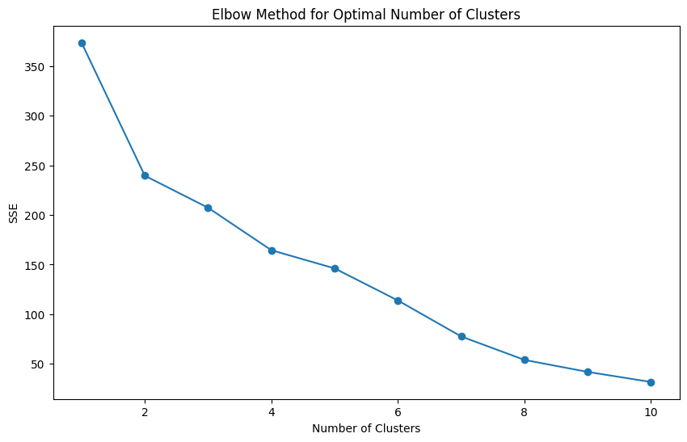

```python
# Transform the text data into numerical features using TfidfVectorizer
vectorizer = TfidfVectorizer(stop_words="english")

X = vectorizer.fit_transform(
    data[[col for col in data.columns if "rating" in col]].astype(str).apply(lambda x: ' '.join(x), axis=1)
)

# Elbow Method to find the optimal number of clusters
sse = []
for k in range(1, 11):
    kmeans = KMeans(
        n_clusters=k, random_state=42
    )  # Iterate over the list of cluster numbers.
    kmeans.fit(
        X
    )  # For each number of clusters, create and fit a K-Means model to the data.
    sse.append(
        kmeans.inertia_
    )  # Append the inertia (SSE) of the fitted model to the SSE list.

# Plot SSE vs. Number of Clusters
plt.figure(figsize=(10, 6))
plt.plot(range(1, 11), sse, marker="o")
plt.xlabel("Number of Clusters")
plt.ylabel("SSE")
plt.title("Elbow Method for Optimal Number of Clusters")
plt.show()
```

# Text Mining

2.1. Text mining is the process of analyzing collections of textual materials in order to capture key concepts and themes and uncover hidden relationships and trends without requiring that you know the precise words or terms that authors have used to express those concepts.

2.2. To make sense of the text and make it useful for various ML techniques, there has to be a numeric way to express the text.

2.3. Your task is to create a count vector and a tfidf vector on the given data (refer to 2. In the resources below).

2.4. Display the count vector and tfidf vector and explain the usage of tfidf.

# Artificial Neural Network (ANN)

3.1. An ANN is (supposed to be) exactly like a human brain but simulated using a software. Like a brain, a NN consist of various layers of “neurons” that work simultaneously to get the output.

3.2. Your task is to apply ANN on the admission dataset used in assignment 2 using code given in tutorial 6. You will have to make necessary changes to the code to make it work for the admission dataset. Hint: encode the target attribute values to binary values .